# Project Poster

Steven Hwang

March 10, 2017

## Introduction

Travelers are increasingly using short term vacation rentals as an alternative to traditional hotels for accomodations. The most popular service for short term vacation rentals is Airbnb, a website that lets anybody rent out their room, apartment, or house. Airbnb’s popularity has created a potential revenue source for property owners. Homeowners with a spare bedroom now have the option to rent it out on their desired timeline. Apartment building owners now have the option to rent units to travelers instead of long term tenants. Central to the decision to become an Airbnb host is the expected revenue. Individuals will only list their properties on Airbnb if they expect to make above a certain amount of money. A model that predicts the rental price of a unit given its attributes can help potential Airbnb hosts decide whether to rent out their unit. The decision to host, however, is more complicated. Hosts have many choices about how to set up their short term vacation rental unit, and each choice may influence the price they can charge. Using Airbnb data from Amdsterdam, we model how the attributes a host can and cannot control about their Airbnb unit influence the amount they charge. Analysis and Interpretation of the model can help future Airbnb hosts anticipate potential revenue and determine the optimal way to set up their short term vacation rental unit.

## Background

- The data for this study was obtained from *insideairbnb* for active listings on 7/4/2016 in Amsterdam, Netherlands.
- The data was reduced to 15 variables of interest for 13849 different listings on Airbnb.com.

| Variables | Type | Description |
| --- | --- | --- |
| Price per night | Account Setting | The price per night of the listing. |
| Host is superhost | Account Setting | Is the host an Airbnb superhost. |
| Room type | Account Setting | The room type of the listing (whole place or room). |
| Accomodates | Account Setting | The number of people the listing accomodates. |
| Profile picture | Account Setting | Does the host has a profile picture. |
| Identity verified | Account Setting | Is the hosts identity verified by Airbnb. |
| Guest included | Account Setting | The number of guests included in the price. |
| Minimum nights | Account Setting | Minimum booking nights. |
| Amenities | Account Setting | Type of amenities included. |
| Beds | Control | The number of beds. |
| Bed type | Control | The type of beds in the listing. |
| Neighbourhood | Control | Neighbourhood the listing is located in. |
| Property type | Control | The property type of the listing. |
| Bathrooms | Control | The number of bathrooms. |
| Bedrooms | Control | The number of bedrooms. |

[figure not shown]

## Methodology & Analysis

We bulit an original regression model including all predictors and all samples. The residual plot shows there exist some outliers and variance of residuals are not constant. The QQ plot shows our data are not from normal distribution which has no effect on the basis of estimators but influences the tests of significance. Since our rule is to guarantee the high accuracy of prediction, we don’t have to pay much attention on the non-normality.

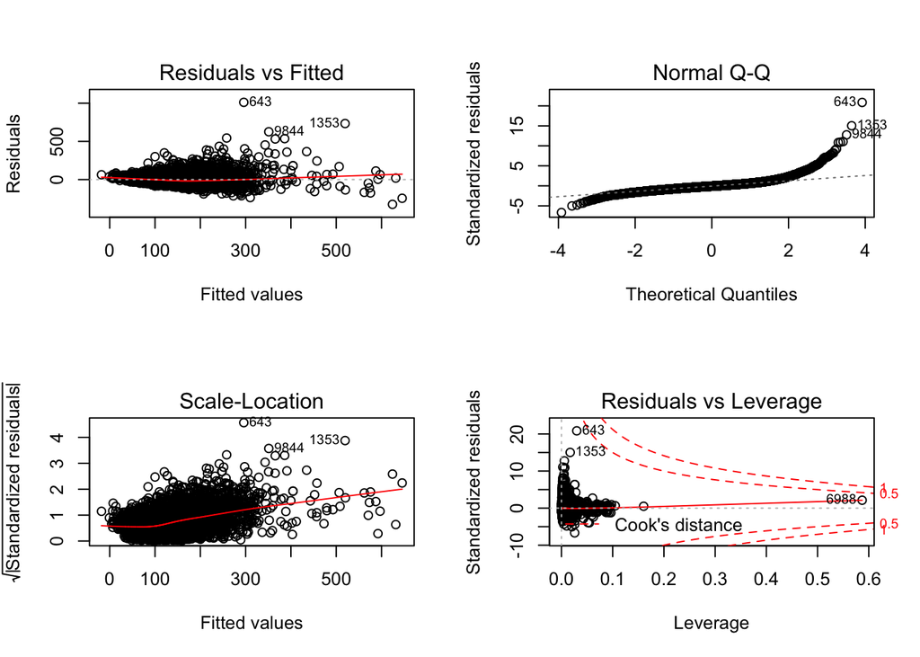

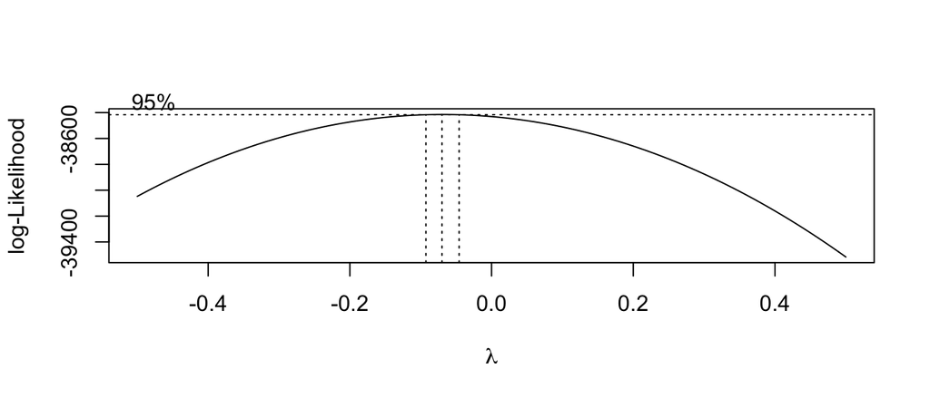

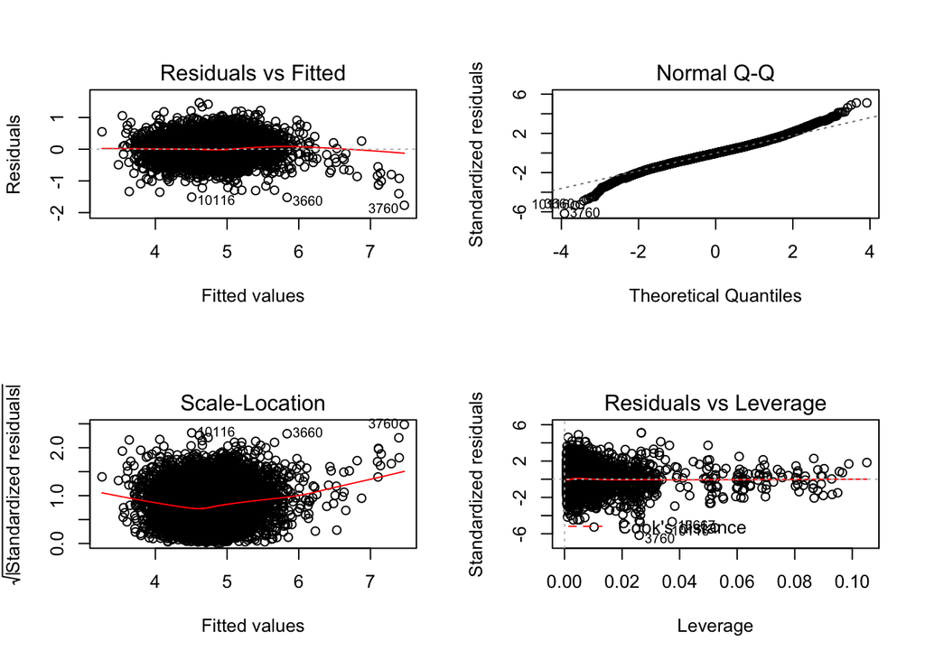

## Results

The expected change in log of y with respect to a one-unit increase in x1 holding all other variables at any fixed value

|  | $\beta$ | exp($\beta$) | SE | p-value |
| --- | --- | --- | --- | --- |
| Intercept | 2.680 | 14.59 | 0.092 | < 2e-16 |
| Host is superhost | 0.070 | 1.07 | 0.009 | 4.86e-14 |
| Room type: Private | 0.397 | 1.49 | 0.008 | < 2e-16 |
| Room type: Entire Place | 0.806 | 2.24 | 0.045 | < 2e-16 |
| Accomodates | 0.076 | 1.08 | 0.004 | < 2e-16 |
| # of Beds | 0.006 | 1.01 | 0.004 | 0.0984 |
| Bed type: Couch | 0.184 | 1.20 | 0.112 | 0.0997 |
| Bed type: Real Bed | 0.076 | 1.08 | 0.076 | 0.1208 |
| Guest included | 0.015 | 1.02 | 0.003 | 5.75e-07 |
| Minimum nights | -0.019 | 0.98 | 0.002 | < 2e-16 |
| Wifi | 0.137 | 1.14 | 0.020 | 2.52e-12 |
| Parking | 0.019 | 1.02 | 0.013 | 0.1415 |
| Smoking | -0.024 | 0.98 | 0.009 | 0.0109 |

## Discussion

Becoming a superhost increases the average price per night by seven percent; hosts should attempt to fulfill the requirements of a superhost. As compared to a shared space, a private room raises the price per night by 50%, and an entire place raises the price 120%; depending on the property, this information can be used to optimize the configuration of an Airbnb rental. Each additional person a unit accommodates raises the price by 7.8% on average, so high density units may be worthwhile. Hosts that require a minimum number of nights charge less for their units, so if the work between stays is minimal, the model suggestions that hosts should not impose a minimum nights requirement. Units with wifi charge around 15% more on average; this information can be used by hosts to decide whether to purchase wifi for their unit. Lastly, units that allow smoking charge less per night, so the model does not indicate that hosts should allow this.

It must be noted that this analysis does not imply that these attributes are the direct cause on price, as the model is based on observational data, not a randomized experiment. Nonetheless, the coefficients of the model provide useful indications for how hosts should set up their Airbnb units. The model can be improved with more data from locations other than Amsterdam, and more variables of rental units. Interaction effects should be considered, as well as nonlinear models. Regardless, a useful model was produced that provides useful insight into Airbnb vacation rentals.